# Data Load

```python
import pandas as pd
df_user_analytics = pd.read_csv("https://storage.googleapis.com/datalynn-datasets/interview-challenge/entertainment-and-media/Adobe_Analytics/UserAnalytics.csv")
```

## Question 1:

Given the surge in mobile users, we are keen to understand how different channels impact user behavior. Leveraging the UserAnalytics table, can you identify any distinct patterns or insights concerning the duration (time_spent) on various channels (channel)?

## Solution:

### Hints:

1. First, group the data by the channel and then get the statistical summary of the time_spent column.
2. Visualizing the distribution of time_spent per channel might offer more insights.
3. Check for seasonality or outliers using timeseries analysis on the last_activity and time_spent columns.

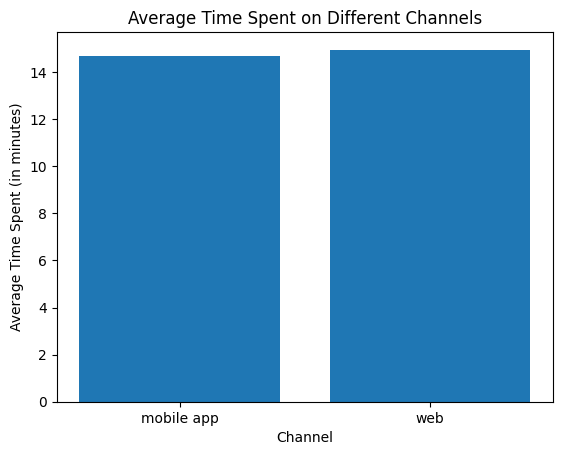

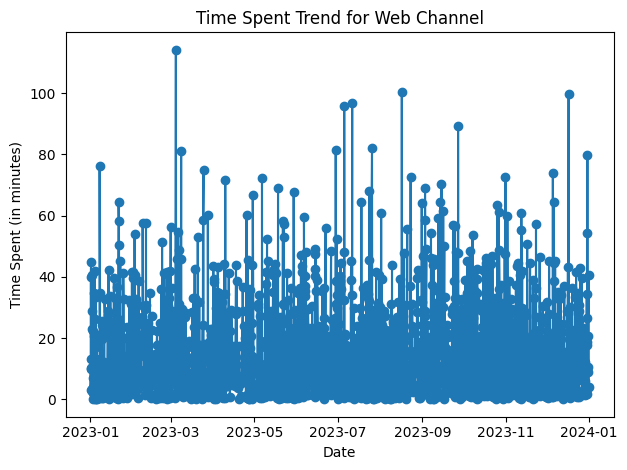

```python
import pandas as pd
import matplotlib.pyplot as plt


# Group by 'channel' and get a summary of 'time_spent'
channel_summary = df_user_analytics.groupby('channel')['time_spent'].describe()

# Plotting the mean time spent on each channel
plt.bar(channel_summary.index, channel_summary['mean'])
plt.ylabel('Average Time Spent (in minutes)')
plt.xlabel('Channel')
plt.title('Average Time Spent on Different Channels')
plt.show()

# If looking for seasonality or outliers
# Convert last_activity to datetime format and then sort
df_user_analytics['last_activity'] = pd.to_datetime(df_user_analytics['last_activity'])
df_user_analytics_sorted = df_user_analytics.sort_values('last_activity')

# Plotting time spent across different days for a given channel (e.g., web)
web_data = df_user_analytics_sorted[df_user_analytics_sorted['channel'] == 'web']
plt.plot_date(web_data['last_activity'], web_data['time_spent'], linestyle='solid')
plt.ylabel('Time Spent (in minutes)')
plt.xlabel('Date')
plt.title('Time Spent Trend for Web Channel')
plt.tight_layout()
plt.show()
```

### Summary:

This solution offers a glance at the average time spent by users on different channels. The bar graph gives a quick comparison across channels, while the timeseries plot helps identify any trends or outliers in user behavior over time.

## Question 2:

Using the `UserAnalytics` table, how would you gauge the relationship between `click_rate` and `conversion_flag`? Does a higher click rate necessarily translate to a higher likelihood of conversion?

## Solution:

### Hints:

1. One way to analyze the relationship is by using scatter plots or correlation metrics.
2. Another method is to segment users based on click rates and compare conversion rates within these segments.
3. Using a statistical hypothesis test like the Chi-squared test might also help understand if there's a significant relationship.

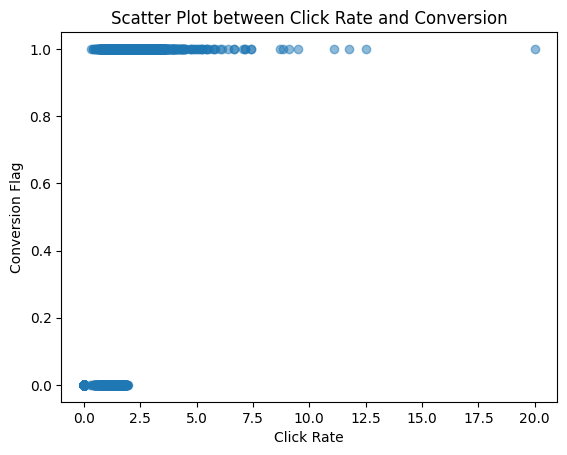

```
Correlation between click rate and conversion flag: 0.47
```

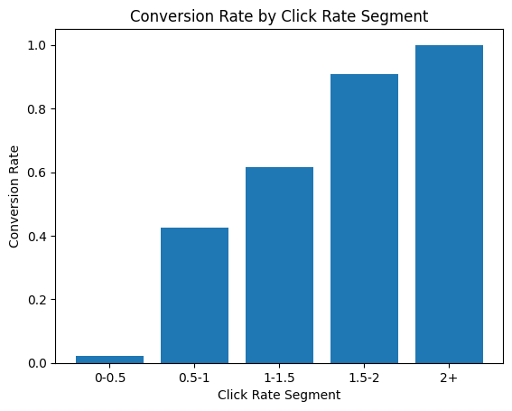

```python
# Scatter plot between click_rate and conversion_flag
plt.scatter(df_user_analytics['click_rate'], df_user_analytics['conversion_flag'], alpha=0.5)
plt.xlabel('Click Rate')
plt.ylabel('Conversion Flag')
plt.title('Scatter Plot between Click Rate and Conversion')
plt.show()

# Correlation coefficient between click_rate and conversion_flag
correlation = df_user_analytics['click_rate'].corr(df_user_analytics['conversion_flag'])
print(f"Correlation between click rate and conversion flag: {correlation:.2f}")

# Segmenting users based on click rates and comparing conversion rates
bins = [0, 0.5, 1, 1.5, 2, float('inf')]
labels = ['0-0.5', '0.5-1', '1-1.5', '1.5-2', '2+']
df_user_analytics['click_rate_segment'] = pd.cut(df_user_analytics['click_rate'], bins=bins, labels=labels, right=False)
conversion_by_segment = df_user_analytics.groupby('click_rate_segment')['conversion_flag'].mean()

plt.bar(conversion_by_segment.index, conversion_by_segment.values)
plt.xlabel('Click Rate Segment')
plt.ylabel('Conversion Rate')
plt.title('Conversion Rate by Click Rate Segment')
plt.show()
```

## Question 3:

We aim to segment users based on their engagement level, determined by `time_spent` and `page_views`. Using the `UserAnalytics` table, devise a clustering mechanism to segment users into distinct groups. Further, can you hypothesize how each segment might differ in their conversion likelihood (`conversion_flag`)?

## Solution:

### Hints:

1. KMeans clustering is a good starting point for segmentation.
2. Before applying clustering, ensure the data is scaled since KMeans is sensitive to feature scaling.
3. Once clusters are identified, analyze the mean conversion rate for each cluster to hypothesize conversion likelihood.

```python
from sklearn.cluster import KMeans
from sklearn.preprocessing import StandardScaler

# Extracting relevant features and scaling
X = df_user_analytics[['time_spent', 'page_views']]
scaler = StandardScaler()
X_scaled = scaler.fit_transform(X)

# Using KMeans clustering
kmeans = KMeans(n_clusters=3, random_state=42, n_init='auto')
df_user_analytics['cluster'] = kmeans.fit_predict(X_scaled)

# Visualizing clusters
plt.scatter(df_user_analytics['time_spent'], df_user_analytics['page_views'], c=df_user_analytics['cluster'], cmap='rainbow')
plt.xlabel('Time Spent')
plt.ylabel('Page Views')
plt.title('User Segmentation based on Engagement')
plt.show()

# Analyzing conversion likelihood for each cluster
conversion_by_cluster = df_user_analytics.groupby('cluster')['conversion_flag'].mean()
print(conversion_by_cluster)
```

[output not shown]

## Question 4:

Based on the `UserAnalytics` data, can you develop a predictive model to determine the likelihood of a user converting in their next session? Ensure to delineate the features you'd employ and identify `conversion_flag` as the target variable.

## Solution:

### Hints:

1. Logistic Regression is a common choice for binary classification problems.
2. Ensure data is split into training and testing sets to validate model performance.
3. Features like time_spent, page_views, and click_rate might be good predictors for conversion.

```python
from sklearn.model_selection import train_test_split
from sklearn.linear_model import LogisticRegression
from sklearn.metrics import accuracy_score

# Defining features and target variable
X = df_user_analytics[['time_spent', 'page_views', 'click_rate']]
y = df_user_analytics['conversion_flag']

# Splitting data into training and testing sets
X_train, X_test, y_train, y_test = train_test_split(X, y, test_size=0.2, random_state=42)

# Applying Logistic Regression
clf = LogisticRegression(random_state=42)
clf.fit(X_train, y_train)

# Predicting on test set and evaluating accuracy
y_pred = clf.predict(X_test)
accuracy = accuracy_score(y_test, y_pred)
print(f"Accuracy of the Logistic Regression model: {accuracy:.2f}")
```

```
Accuracy of the Logistic Regression model: 0.92
```

### Summary:

The solution uses Logistic Regression to predict user conversions based on their engagement metrics.